# 10: More `purrr`ing

BSTA 526: R Programming for Health Data Science

Author

Affiliation

Meike Niederhausen, PhD & Jessica Minnier, PhD

OHSU-PSU School of Public Health

Published

March 5, 2026

Modified

March 12, 2026

# 1 Welcome to R Programming: Part 10!

[figure not shown]

Today we will learn more about iterating in R with `purrr`.

Before you get started:

> Remember to save this notebook under a new name, such as `part_10_b526_YOURNAME.qmd`.
- Load the packages in the setup code chunk

## 1.1 Learning Objectives

- **Use** `map()` functions from the `purrr` package to iterate functions
- **Nest** datasets into list-columns, and iterate statistical modeling and/or visualization functions over those elements
- **Use** `map2()` from the `purrr` package to iterate functions across two inputs
- **Learn** how to iterate regression modeling across different model variables

## 1.2 Select all squares with pipes before moving on…

[figure not shown]

# 2 Last time: iteration with `purrr`

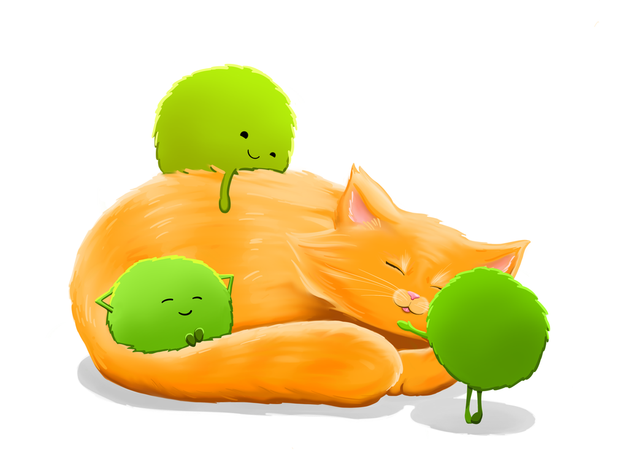

[Artwork by @allison_horst](https://allisonhorst.com/wickham-tidy-bakers)

Please look at the [purrr cheatsheet](https://rstudio.github.io/cheatsheets/purrr.pdf).

## 2.1 Why `purrr`?

From the first edition of [R for Data Science](https://r4ds.had.co.nz/iteration.html):

> The goal of using purrr functions instead of for loops is to allow you to break common list manipulation challenges into independent pieces:
> - How can you solve the problem for a single element of the list? Once you’ve solved that problem, purrr takes care of generalising your solution to every element in the list.
> - If you’re solving a complex problem, how can you break it down into bite-sized pieces that allow you to advance one small step towards a solution? With purrr, you get lots of small pieces that you can compose together with the pipe.

> This structure makes it easier to solve new problems. It also makes it easier to understand your solutions to old problems when you re-read your old code.

## 2.2 `purrr::map()` applied to lists

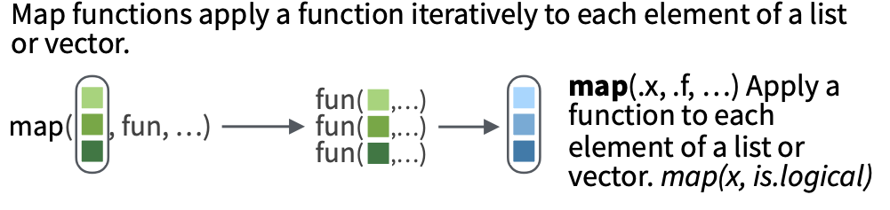

[From old 2017 purrr cheatsheet](https://evoldyn.gitlab.io/evomics-2018/ref-sheets/R_purrr.pdf)

Remember `purrr::map()` from part 8:

- `purrr::map()` lets us *apply* a function to each element of a list (or data frame).
- It will always return a list with the number of elements that is the same as the list we input it with.
- Each slot of the returned list will contain the output of the functions applied to each element of the input list.

The way to read a `map()` statement is:

`map(.x = LIST_OBJECT, .f = FUNCTION_TO_APPLY)`

# 3 `purrr::map()` on **nested** data frames

- Last time we learned how to apply `map()` on a *list of data frames* (Part 8, Section 5)
- Typically we have just one data frame though, and we want to perform the same operation on subsets of that data frame.

## 3.1 Example

Example: on your homework the `penguins` data was grouped by `species` and `group_split()` was used to create a *list of data frames*:

```r
# split one data frame into three data frames defined by the species (grouping variable)
# .keep = TRUE keeps the species (grouping) column in the data sets
penguins_by_species <- penguins  %>%
  group_by(species) %>%
  group_split(.keep = TRUE)

penguins_by_species  # lists are numbered
```

```
<list_of<
  tbl_df<
    species          : factor<b22a0>
    island           : factor<ccf33>
    bill_length_mm   : double
    bill_depth_mm    : double
    flipper_length_mm: integer
    body_mass_g      : integer
    sex              : factor<8f119>
    year             : integer
  >
>[3]>
[[1]]
# A tibble: 152 × 8
   species island    bill_length_mm bill_depth_mm flipper_length_mm body_mass_g
   <fct>   <fct>              <dbl>         <dbl>             <int>       <int>
 1 Adelie  Torgersen           39.1          18.7               181        3750
 2 Adelie  Torgersen           39.5          17.4               186        3800
 3 Adelie  Torgersen           40.3          18                 195        3250
 4 Adelie  Torgersen           NA            NA                  NA          NA
 5 Adelie  Torgersen           36.7          19.3               193        3450
 6 Adelie  Torgersen           39.3          20.6               190        3650
 7 Adelie  Torgersen           38.9          17.8               181        3625
 8 Adelie  Torgersen           39.2          19.6               195        4675
 9 Adelie  Torgersen           34.1          18.1               193        3475
10 Adelie  Torgersen           42            20.2               190        4250
# ℹ 142 more rows
# ℹ 2 more variables: sex <fct>, year <int>

[[2]]
# A tibble: 68 × 8
   species   island bill_length_mm bill_depth_mm flipper_length_mm body_mass_g
   <fct>     <fct>           <dbl>         <dbl>             <int>       <int>
 1 Chinstrap Dream            46.5          17.9               192        3500
 2 Chinstrap Dream            50            19.5               196        3900
 3 Chinstrap Dream            51.3          19.2               193        3650
 4 Chinstrap Dream            45.4          18.7               188        3525
 5 Chinstrap Dream            52.7          19.8               197        3725
 6 Chinstrap Dream            45.2          17.8               198        3950
 7 Chinstrap Dream            46.1          18.2               178        3250
 8 Chinstrap Dream            51.3          18.2               197        3750
 9 Chinstrap Dream            46            18.9               195        4150
10 Chinstrap Dream            51.3          19.9               198        3700
# ℹ 58 more rows
# ℹ 2 more variables: sex <fct>, year <int>

[[3]]
# A tibble: 124 × 8
   species island bill_length_mm bill_depth_mm flipper_length_mm body_mass_g
   <fct>   <fct>           <dbl>         <dbl>             <int>       <int>
 1 Gentoo  Biscoe           46.1          13.2               211        4500
 2 Gentoo  Biscoe           50            16.3               230        5700
 3 Gentoo  Biscoe           48.7          14.1               210        4450
 4 Gentoo  Biscoe           50            15.2               218        5700
 5 Gentoo  Biscoe           47.6          14.5               215        5400
 6 Gentoo  Biscoe           46.5          13.5               210        4550
 7 Gentoo  Biscoe           45.4          14.6               211        4800
 8 Gentoo  Biscoe           46.7          15.3               219        5200
 9 Gentoo  Biscoe           43.3          13.4               209        4400
10 Gentoo  Biscoe           46.8          15.4               215        5150
# ℹ 114 more rows
# ℹ 2 more variables: sex <fct>, year <int>
```

```r
penguin_names <- levels(penguins$species)

names(penguins_by_species) <- penguin_names

penguins_by_species # lists are now named with species names
```

```
<list_of<
  tbl_df<
    species          : factor<b22a0>
    island           : factor<ccf33>
    bill_length_mm   : double
    bill_depth_mm    : double
    flipper_length_mm: integer
    body_mass_g      : integer
    sex              : factor<8f119>
    year             : integer
  >
>[3]>
$Adelie
# A tibble: 152 × 8
   species island    bill_length_mm bill_depth_mm flipper_length_mm body_mass_g
   <fct>   <fct>              <dbl>         <dbl>             <int>       <int>
 1 Adelie  Torgersen           39.1          18.7               181        3750
 2 Adelie  Torgersen           39.5          17.4               186        3800
 3 Adelie  Torgersen           40.3          18                 195        3250
 4 Adelie  Torgersen           NA            NA                  NA          NA
 5 Adelie  Torgersen           36.7          19.3               193        3450
 6 Adelie  Torgersen           39.3          20.6               190        3650
 7 Adelie  Torgersen           38.9          17.8               181        3625
 8 Adelie  Torgersen           39.2          19.6               195        4675
 9 Adelie  Torgersen           34.1          18.1               193        3475
10 Adelie  Torgersen           42            20.2               190        4250
# ℹ 142 more rows
# ℹ 2 more variables: sex <fct>, year <int>

$Chinstrap
# A tibble: 68 × 8
   species   island bill_length_mm bill_depth_mm flipper_length_mm body_mass_g
   <fct>     <fct>           <dbl>         <dbl>             <int>       <int>
 1 Chinstrap Dream            46.5          17.9               192        3500
 2 Chinstrap Dream            50            19.5               196        3900
 3 Chinstrap Dream            51.3          19.2               193        3650
 4 Chinstrap Dream            45.4          18.7               188        3525
 5 Chinstrap Dream            52.7          19.8               197        3725
 6 Chinstrap Dream            45.2          17.8               198        3950
 7 Chinstrap Dream            46.1          18.2               178        3250
 8 Chinstrap Dream            51.3          18.2               197        3750
 9 Chinstrap Dream            46            18.9               195        4150
10 Chinstrap Dream            51.3          19.9               198        3700
# ℹ 58 more rows
# ℹ 2 more variables: sex <fct>, year <int>

$Gentoo
# A tibble: 124 × 8
   species island bill_length_mm bill_depth_mm flipper_length_mm body_mass_g
   <fct>   <fct>           <dbl>         <dbl>             <int>       <int>
 1 Gentoo  Biscoe           46.1          13.2               211        4500
 2 Gentoo  Biscoe           50            16.3               230        5700
 3 Gentoo  Biscoe           48.7          14.1               210        4450
 4 Gentoo  Biscoe           50            15.2               218        5700
 5 Gentoo  Biscoe           47.6          14.5               215        5400
 6 Gentoo  Biscoe           46.5          13.5               210        4550
 7 Gentoo  Biscoe           45.4          14.6               211        4800
 8 Gentoo  Biscoe           46.7          15.3               219        5200
 9 Gentoo  Biscoe           43.3          13.4               209        4400
10 Gentoo  Biscoe           46.8          15.4               215        5150
# ℹ 114 more rows
# ℹ 2 more variables: sex <fct>, year <int>
```

## 3.2 List-columns

- A **list-column** is a column of a data frame that contains lists.
- We are familiar with vector-columns that contain a vector of character or numeric (usually) data.
- This is the same idea, except each element of the column is a list.

Example:

```r
mydf <- tibble(
  patientid = c(1123, 2534, 13253),
  date = c("2021-01","2022-02","2022-03"),
  listcol = list(a = c("a","b"),
                 b = 1:3,
                 c = "c"))
mydf
```

```
# A tibble: 3 × 3
  patientid date    listcol
      <dbl> <chr>   <named list>
1      1123 2021-01 <chr [2]>
2      2534 2022-02 <int [3]>
3     13253 2022-03 <chr [1]>
```

- You can see above that the `listcol` column is of type list, and we see abbreviated information about it.
- We can see a little bit more with glimpse:

```r
glimpse(mydf)
```

```
Rows: 3
Columns: 3
$ patientid <dbl> 1123, 2534, 13253
$ date      <chr> "2021-01", "2022-02", "2022-03"
$ listcol   <named list> <"a", "b">, <1, 2, 3>, "c"
```

## 3.3 Nesting

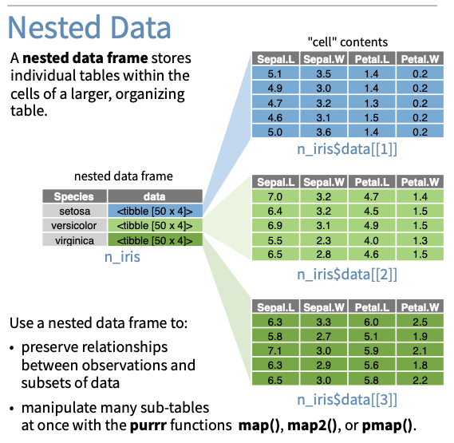

[From old 2017 purrr cheatsheet](https://evoldyn.gitlab.io/evomics-2018/ref-sheets/R_purrr.pdf)

So what does this have to do with mapping data frames? Below we are nesting our data frame by the grouping variable, species:

```r
# cute name, huh?
penguins_nested <- penguins %>%
  mutate(
    bill_length_long = case_when(
      bill_length_mm >= 44 ~ "Yes",  # median is 44.45, mean is 43.92
      bill_length_mm < 44 ~ "No"),
    bill_length_long = factor(bill_length_long)
    ) %>%
  # use species column to define the new rows
  group_by(species) %>%
  nest()

penguins_nested
```

```
# A tibble: 3 × 2
# Groups:   species [3]
  species   data
  <fct>     <list>
1 Adelie    <tibble [152 × 8]>
2 Gentoo    <tibble [124 × 8]>
3 Chinstrap <tibble [68 × 8]>
```

```r
glimpse(penguins_nested)
```

```
Rows: 3
Columns: 2
Groups: species [3]
$ species <fct> Adelie, Gentoo, Chinstrap
$ data    <list> [<tbl_df[152 x 8]>], [<tbl_df[124 x 8]>], [<tbl_df[68 x 8]>]
```

**Note**: There is also the `dplyr` function `group_nest()`, which was used at the end of part 8 and does the same thing as `group_by()` followed by `nest()`. This is in lifecycle “experimental” though and may be deprecated in the future.

## 3.4 Look at the nested datasets

We can pull out our data column with the `$` and see it is a list:

```r
penguins_nested$data
```

```
[[1]]
# A tibble: 152 × 8
   island bill_length_mm bill_depth_mm flipper_length_mm body_mass_g sex    year
   <fct>           <dbl>         <dbl>             <int>       <int> <fct> <int>
 1 Torge…           39.1          18.7               181        3750 male   2007
 2 Torge…           39.5          17.4               186        3800 fema…  2007
 3 Torge…           40.3          18                 195        3250 fema…  2007
 4 Torge…           NA            NA                  NA          NA <NA>   2007
 5 Torge…           36.7          19.3               193        3450 fema…  2007
 6 Torge…           39.3          20.6               190        3650 male   2007
 7 Torge…           38.9          17.8               181        3625 fema…  2007
 8 Torge…           39.2          19.6               195        4675 male   2007
 9 Torge…           34.1          18.1               193        3475 <NA>   2007
10 Torge…           42            20.2               190        4250 <NA>   2007
# ℹ 142 more rows
# ℹ 1 more variable: bill_length_long <fct>

[[2]]
# A tibble: 124 × 8
   island bill_length_mm bill_depth_mm flipper_length_mm body_mass_g sex    year
   <fct>           <dbl>         <dbl>             <int>       <int> <fct> <int>
 1 Biscoe           46.1          13.2               211        4500 fema…  2007
 2 Biscoe           50            16.3               230        5700 male   2007
 3 Biscoe           48.7          14.1               210        4450 fema…  2007
 4 Biscoe           50            15.2               218        5700 male   2007
 5 Biscoe           47.6          14.5               215        5400 male   2007
 6 Biscoe           46.5          13.5               210        4550 fema…  2007
 7 Biscoe           45.4          14.6               211        4800 fema…  2007
 8 Biscoe           46.7          15.3               219        5200 male   2007
 9 Biscoe           43.3          13.4               209        4400 fema…  2007
10 Biscoe           46.8          15.4               215        5150 male   2007
# ℹ 114 more rows
# ℹ 1 more variable: bill_length_long <fct>

[[3]]
# A tibble: 68 × 8
   island bill_length_mm bill_depth_mm flipper_length_mm body_mass_g sex    year
   <fct>           <dbl>         <dbl>             <int>       <int> <fct> <int>
 1 Dream            46.5          17.9               192        3500 fema…  2007
 2 Dream            50            19.5               196        3900 male   2007
 3 Dream            51.3          19.2               193        3650 male   2007
 4 Dream            45.4          18.7               188        3525 fema…  2007
 5 Dream            52.7          19.8               197        3725 male   2007
 6 Dream            45.2          17.8               198        3950 fema…  2007
 7 Dream            46.1          18.2               178        3250 fema…  2007
 8 Dream            51.3          18.2               197        3750 male   2007
 9 Dream            46            18.9               195        4150 fema…  2007
10 Dream            51.3          19.9               198        3700 male   2007
# ℹ 58 more rows
# ℹ 1 more variable: bill_length_long <fct>
```

```r
class(penguins_nested$data)
```

```
[1] "list"
```

Which means we can index it with the `[[]]` double brackets:

```r
# The first "row" which is the first element of the list
penguins_nested$data[[1]]
```

```
# A tibble: 152 × 8
   island bill_length_mm bill_depth_mm flipper_length_mm body_mass_g sex    year
   <fct>           <dbl>         <dbl>             <int>       <int> <fct> <int>
 1 Torge…           39.1          18.7               181        3750 male   2007
 2 Torge…           39.5          17.4               186        3800 fema…  2007
 3 Torge…           40.3          18                 195        3250 fema…  2007
 4 Torge…           NA            NA                  NA          NA <NA>   2007
 5 Torge…           36.7          19.3               193        3450 fema…  2007
 6 Torge…           39.3          20.6               190        3650 male   2007
 7 Torge…           38.9          17.8               181        3625 fema…  2007
 8 Torge…           39.2          19.6               195        4675 male   2007
 9 Torge…           34.1          18.1               193        3475 <NA>   2007
10 Torge…           42            20.2               190        4250 <NA>   2007
# ℹ 142 more rows
# ℹ 1 more variable: bill_length_long <fct>
```

**Note that `species` is no longer a column in these datasets!!!**

# 4 `mutate` and `map` nested data

How do we apply functions to this nested data set?

- We can use `mutate()` to mutate the list column along with `map()`!
- We use `mutate()` because we are mutating a *COLUMN* (which happens to be a list column) in a data frame.

[figure not shown]

[From old 2017 purrr cheatsheet](https://evoldyn.gitlab.io/evomics-2018/ref-sheets/R_purrr.pdf)

## 4.1 Example: `dim()`

Let’s see a simple example before running our model.

Remember how `penguins_nested` looks:

```r
glimpse(penguins_nested)
```

```
Rows: 3
Columns: 2
Groups: species [3]
$ species <fct> Adelie, Gentoo, Chinstrap
$ data    <list> [<tbl_df[152 x 8]>], [<tbl_df[124 x 8]>], [<tbl_df[68 x 8]>]
```

- The column that we want to mutate/map is called `data`.
- We want to create a new column by applying a function to that list-column.

```r
# Create a new column called dim_data (it will be a list-column)
# First argument of map is the name of the column with the list of data
# Second argument of map is the function name (without parens)

penguins_nested <- penguins_nested %>%
  # new column name = map(list-column-name, function-to-apply)
  mutate(dim_data = map(.x = data, .f = dim))

penguins_nested
```

```
# A tibble: 3 × 3
# Groups:   species [3]
  species   data               dim_data
  <fct>     <list>             <list>
1 Adelie    <tibble [152 × 8]> <int [2]>
2 Gentoo    <tibble [124 × 8]> <int [2]>
3 Chinstrap <tibble [68 × 8]>  <int [2]>
```

```r
penguins_nested %>%
  glimpse()
```

```
Rows: 3
Columns: 3
Groups: species [3]
$ species  <fct> Adelie, Gentoo, Chinstrap
$ data     <list> [<tbl_df[152 x 8]>], [<tbl_df[124 x 8]>], [<tbl_df[68 x 8]>]
$ dim_data <list> <152, 8>, <124, 8>, <68, 8>
```

```r
# a list of dimensions
penguins_nested$dim_data
```

```
[[1]]
[1] 152   8

[[2]]
[1] 124   8

[[3]]
[1] 68  8
```

## 4.2 Example: logistic regression with `glm()`

**intro**

- Suppose we want to look at the association between having a long bill length (`bill_length_long`) and the variable bill depth.
  - Since the outcome is a binary variable. we use a logistic regression model (covered in BSTA 513).
- Note that we no longer have a column `species` in the data subsets in the list-column.
  - The species information remained in the `species` column of the `penguins_nested` tibble.
  - The list-column contains every column *except* `species`.

**Create run_glm function**

```r
# function only takes data frame as an input
# runs glm
run_glm <- function(df) {
  # fit a logistic regression model with these data
  # glm(bill_length_long ~ sex, data = df)
  glm(bill_length_long ~ bill_depth_mm,
      family = "binomial",
      data = df)
}
```

Test function:

```r
run_glm(df = penguins_nested$data[[1]])
```

```
Call:  glm(formula = bill_length_long ~ bill_depth_mm, family = "binomial",
    data = df)

Coefficients:
  (Intercept)  bill_depth_mm
     -20.3177         0.8927

Degrees of Freedom: 150 Total (i.e. Null);  149 Residual
  (1 observation deleted due to missingness)
Null Deviance:      43.91
Residual Deviance: 37.99    AIC: 41.99
```

**map it!**

```r
# create a new column called model_out (it will be a list-column)
# first argument of map is the name of the column with the list of data
# second argument of map is the function name (no parens)

penguins_nested <- penguins_nested %>%
  # new column name = map(list-column-name, function-to-apply)
  mutate(model_out = map(.x = data, .f = run_glm))

penguins_nested
```

```
# A tibble: 3 × 4
# Groups:   species [3]
  species   data               dim_data  model_out
  <fct>     <list>             <list>    <list>
1 Adelie    <tibble [152 × 8]> <int [2]> <glm>
2 Gentoo    <tibble [124 × 8]> <int [2]> <glm>
3 Chinstrap <tibble [68 × 8]>  <int [2]> <glm>
```

```r
# model output for each species:
penguins_nested$model_out
```

```
[[1]]

Call:  glm(formula = bill_length_long ~ bill_depth_mm, family = "binomial",
    data = df)

Coefficients:
  (Intercept)  bill_depth_mm
     -20.3177         0.8927

Degrees of Freedom: 150 Total (i.e. Null);  149 Residual
  (1 observation deleted due to missingness)
Null Deviance:      43.91
Residual Deviance: 37.99    AIC: 41.99

[[2]]

Call:  glm(formula = bill_length_long ~ bill_depth_mm, family = "binomial",
    data = df)

Coefficients:
  (Intercept)  bill_depth_mm
      -24.895          1.857

Degrees of Freedom: 122 Total (i.e. Null);  121 Residual
  (1 observation deleted due to missingness)
Null Deviance:      91.22
Residual Deviance: 69.5     AIC: 73.5

[[3]]

Call:  glm(formula = bill_length_long ~ bill_depth_mm, family = "binomial",
    data = df)

Coefficients:
  (Intercept)  bill_depth_mm
      -27.082          1.661

Degrees of Freedom: 67 Total (i.e. Null);  66 Residual
Null Deviance:      40.59
Residual Deviance: 29.86    AIC: 33.86
```

**Why do we need to use map()?**

In other words, why doesn’t this work:

```r
# DOES NOT WORK
penguins_nested %>%
  mutate(model_out = run_glm(data))
```

**Tidy the output**

- Note: with the `tidy` option `exponentiate = TRUE` our model coefficients are now odds ratios instead of log-odds.

```r
penguins_nested <- penguins_nested %>%
  mutate(tidy_glm = map(.x = model_out, ~ tidy(.x, exponentiate = TRUE)))

penguins_nested
```

```
# A tibble: 3 × 5
# Groups:   species [3]
  species   data               dim_data  model_out tidy_glm
  <fct>     <list>             <list>    <list>    <list>
1 Adelie    <tibble [152 × 8]> <int [2]> <glm>     <tibble [2 × 5]>
2 Gentoo    <tibble [124 × 8]> <int [2]> <glm>     <tibble [2 × 5]>
3 Chinstrap <tibble [68 × 8]>  <int [2]> <glm>     <tibble [2 × 5]>
```

```r
penguins_nested$tidy_glm
```

```
[[1]]
# A tibble: 2 × 5
  term               estimate std.error statistic p.value
  <chr>                 <dbl>     <dbl>     <dbl>   <dbl>
1 (Intercept)   0.00000000150     7.52      -2.70 0.00692
2 bill_depth_mm 2.44              0.383      2.33 0.0199

[[2]]
# A tibble: 2 × 5
  term          estimate std.error statistic  p.value
  <chr>            <dbl>     <dbl>     <dbl>    <dbl>
1 (Intercept)   1.54e-11     7.31      -3.41 0.000659
2 bill_depth_mm 6.40e+ 0     0.517      3.59 0.000325

[[3]]
# A tibble: 2 × 5
  term          estimate std.error statistic p.value
  <chr>            <dbl>     <dbl>     <dbl>   <dbl>
1 (Intercept)   1.73e-12    11.4       -2.37  0.0180
2 bill_depth_mm 5.26e+ 0     0.664      2.50  0.0124
```

**unnest() the output**

- The function `unnest()` will “stretch out” the list-column into a stacked data frame (i.e. row-binding).
- It’s basically the reverse operation of `nest()`. Try it out and see what it looks like:

```r
glm_unnest <- penguins_nested %>%
  select(species, tidy_glm) %>%
  # use unnest to stack the data frames in model_out
  # use cols to specify the columns you want to unnest
  unnest(cols = c(tidy_glm))

glm_unnest
```

```
# A tibble: 6 × 6
# Groups:   species [3]
  species   term          estimate std.error statistic  p.value
  <fct>     <chr>            <dbl>     <dbl>     <dbl>    <dbl>
1 Adelie    (Intercept)   1.50e- 9     7.52      -2.70 0.00692
2 Adelie    bill_depth_mm 2.44e+ 0     0.383      2.33 0.0199
3 Gentoo    (Intercept)   1.54e-11     7.31      -3.41 0.000659
4 Gentoo    bill_depth_mm 6.40e+ 0     0.517      3.59 0.000325
5 Chinstrap (Intercept)   1.73e-12    11.4       -2.37 0.0180
6 Chinstrap bill_depth_mm 5.26e+ 0     0.664      2.50 0.0124
```

If we only want the rows for the term `bill_depth_mm` we can filter the tibble:

```r
glm_unnest %>%
  filter(term != "(Intercept)") %>%
  select(species, estimate, std.error, p.value) %>%
  gt()
```

| estimate | std.error | p.value |
| --- | --- | --- |
| Adelie |  |  |
| 2.441721 | 0.3833399 | 0.0198722530 |
| Gentoo |  |  |
| 6.401765 | 0.5165017 | 0.0003249947 |
| Chinstrap |  |  |
| 5.263466 | 0.6642757 | 0.0124140226 |

**Warning!**

Note that `list_rbind()` does not work here since our tibble is grouped by species.

```r
# DOES NOT WORK

penguins_nested %>% list_rbind(tidy_glm)

# Error in `list_rbind()`:
# ! `x` must be a list, not a <grouped_df/tbl_df/tbl/data.frame>
#   object.
```

## 4.3 Challenge 1

1. Unnest the `dim_data` column of `penguins_nested`.
2. Add a list-column to `penguins_nested` with the `glance()` values for the logistic regression model. Then unnest the values and keep only the columns with species and the number of observations (`nobs`).

# 5 `map2()`: map over two inputs

## 5.1 `map2()`

- The `map2()` function maps a function over two lists
- In the example below we will use 2 columns from our nested data frame.

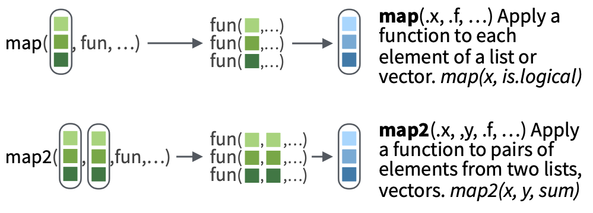

[From old 2017 purrr cheatsheet](https://evoldyn.gitlab.io/evomics-2018/ref-sheets/R_purrr.pdf)

`?map2`: “map over multiple inputs simultaneously.” It takes the first two arguments:

- `.x` and `.y`, Vectors of the *same length*, a vector of length 1 will be recycled
- `.f` a function

The way to read a `map2()` statement is:

`map2(.x = FIRST_LIST_NAME, .y = SECOND_LIST_NAME, .f = FUNCTION_TO_APPLY)`

## 5.2 Example: `build_scatterplot()` function

- Note that the `build_scatterplot()` function has two inputs: df and species

```r
build_scatterplot <- function(df, species){
  ggplot(df) +
    aes(x = bill_depth_mm, y = bill_length_mm) +
    geom_point() +
    geom_smooth(method = "lm") +
    labs(title = species)
}
```

- Now we call `map2()` inside `mutate()` similar to the way we used `map()` inside `mutate()` up above,
  - but we *specify our two column names* first as the first two arguments

```r
penguins_nested <- penguins_nested %>%
  # create a new list column plot_out
  mutate(plot_out = map2(
    # first argument is going in the df = slot of build_scatterplot
    .x = data,
    # second argument is going in the df = species slot of build_Scatterplot
    .y = species,
    # name of function
    .f = build_scatterplot))

# or simply:
penguins_plotdata <- penguins_nested %>%
  mutate(plot_out = map2(data, species, build_scatterplot))

# we now have a list-column containing ggplots!
penguins_plotdata
```

```
# A tibble: 3 × 6
# Groups:   species [3]
  species   data               dim_data  model_out tidy_glm         plot_out
  <fct>     <list>             <list>    <list>    <list>           <list>
1 Adelie    <tibble [152 × 8]> <int [2]> <glm>     <tibble [2 × 5]> <ggplt2::>
2 Gentoo    <tibble [124 × 8]> <int [2]> <glm>     <tibble [2 × 5]> <ggplt2::>
3 Chinstrap <tibble [68 × 8]>  <int [2]> <glm>     <tibble [2 × 5]> <ggplt2::>
```

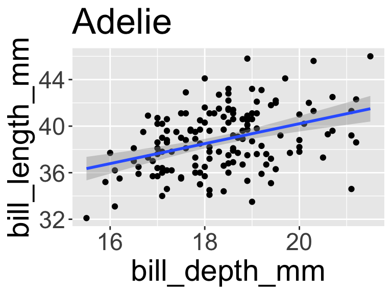

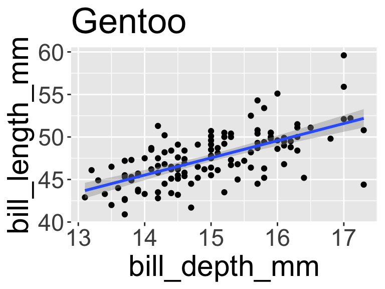

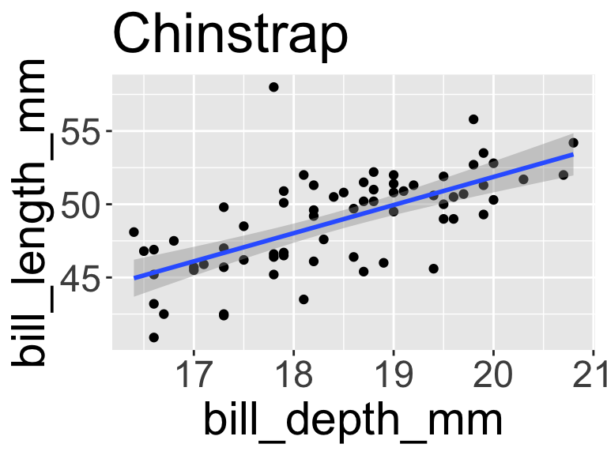

```r
# We can show all our plots by calling the vector:
penguins_plotdata$plot_out
```

## 5.3 `ggpubr::ggarrange()`

There’s a function `ggarrange()` in the package `ggpubr` which will put multiple ggplots on the same figure for you:

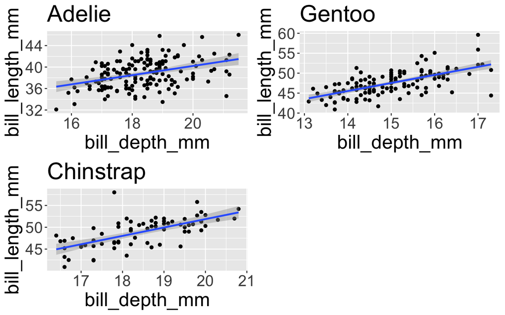

```r
ggpubr::ggarrange(plotlist = penguins_plotdata$plot_out)
```

# 6 Mapping lists of variables for regression modeling

- Below we will use the [`reformulate()`](https://www.r-bloggers.com/2023/06/simplifying-model-formulas-with-the-r-function-reformulate/) function to create a regression formula to use when running a regression model.
- This will be very handy for running many regression models at once.

## 6.1 `reformulate` for regression formula

- Recall that when running a regression model using `lm()`, the first parameter being specified is a formula.
- In the example below using the `penguins` data, we specify `formula = flipper_length_mm ~ bill_depth_mm + species`:

```r
lm(formula = flipper_length_mm ~ bill_depth_mm + species,
   data = penguins) %>% tidy()
```

```
# A tibble: 4 × 5
  term             estimate std.error statistic   p.value
  <chr>               <dbl>     <dbl>     <dbl>     <dbl>
1 (Intercept)        137.       5.18      26.4  3.37e- 84
2 bill_depth_mm        2.89     0.281     10.3  1.05e- 21
3 speciesChinstrap     5.66     0.848      6.67 1.07e- 10
4 speciesGentoo       37.0      1.18      31.3  6.87e-102
```

- Instead of specifying the formula within `lm()`, we can first create the formula as an R object, and then refer to the R object within `lm()`.
- Below we create the formula using the `reformulate()` function. The `termlabels` are the independent variables and `response` the dependent variable of the model:

```r
penguin_formula <- reformulate(termlabels = c("bill_depth_mm", "species"),
                               response = "flipper_length_mm")
penguin_formula
```

```
flipper_length_mm ~ bill_depth_mm + species
```

```r
lm(formula = penguin_formula, data = penguins) %>%
  tidy()
```

```
# A tibble: 4 × 5
  term             estimate std.error statistic   p.value
  <chr>               <dbl>     <dbl>     <dbl>     <dbl>
1 (Intercept)        137.       5.18      26.4  3.37e- 84
2 bill_depth_mm        2.89     0.281     10.3  1.05e- 21
3 speciesChinstrap     5.66     0.848      6.67 1.07e- 10
4 speciesGentoo       37.0      1.18      31.3  6.87e-102
```

- The advantage of creating a formula this way, is that we can then specify the `termlabels` and `response` as R objects as well:

```r
covariates <- c("bill_depth_mm", "species")
outcome <- "flipper_length_mm"

penguin_formula <- reformulate(termlabels = covariates,
                       response = outcome)
penguin_formula
```

```
flipper_length_mm ~ bill_depth_mm + species
```

```r
lm(formula = penguin_formula, data = penguins) %>% tidy()
```

```
# A tibble: 4 × 5
  term             estimate std.error statistic   p.value
  <chr>               <dbl>     <dbl>     <dbl>     <dbl>
1 (Intercept)        137.       5.18      26.4  3.37e- 84
2 bill_depth_mm        2.89     0.281     10.3  1.05e- 21
3 speciesChinstrap     5.66     0.848      6.67 1.07e- 10
4 speciesGentoo       37.0      1.18      31.3  6.87e-102
```

## 6.2 Create function for regression model using `reformulate()`

- Using `reformulate()` to run a regression model lets us more easily specify the variables that go into a model when using function.
- Below is the function `run_regression` that can be used to run a linear model:

```r
# Function to run linear regression with specified covariates
run_regression <- function(covariates, outcome, dataset) {
  formula <- reformulate(termlabels = covariates,
                         response = outcome)
  lm(formula, data = dataset)
}
```

- An example using the function `run_regression` with the `penguins` data:

```r
penguins_covariates <- c("bill_depth_mm", "species")

lm_pengiuns <- run_regression(covariates = penguins_covariates,
               outcome = "flipper_length_mm",
               dataset = penguins)

tidy(lm_pengiuns)
```

```
# A tibble: 4 × 5
  term             estimate std.error statistic   p.value
  <chr>               <dbl>     <dbl>     <dbl>     <dbl>
1 (Intercept)        137.       5.18      26.4  3.37e- 84
2 bill_depth_mm        2.89     0.281     10.3  1.05e- 21
3 speciesChinstrap     5.66     0.848      6.67 1.07e- 10
4 speciesGentoo       37.0      1.18      31.3  6.87e-102
```

## 6.3 Example from cannabis use study

**Background**

- Data are from the baseline time point of an ongoing longitudinal study investigating relationships between pain, mental health, cannabis use, and prescribed opioid doses.
- Participants are Veterans from across the country that are on long-term opioid therapy and have recently tested positive for cannabis use via periodic urine drug testing.
- Most of the variables in the dataset are from the baseline survey participants completed.
  - Variables are described in the questions below where they are being use.
- The data for this example are a random sample of the actual dataset and only include a small subset of all the variables data were collected on. Some variables have had their values slightly altered to further de-identify the data.

**Data**

```r
load(here::here("part10", "data", "ddd.Rdata"))

glimpse(ddd)
```

```
Rows: 250
Columns: 21
$ pptid                 <chr> "258", "484", "237", "023", "033", "510", "545",…
$ gender                <dbl> 1, 1, 1, 1, 2, 1, 1, 1, 1, 1, 1, 4, 1, 2, 1, 1, …
$ Age                   <dbl> 59.14031, 39.14031, 68.14031, 77.14031, 61.14031…
$ Education             <chr> "Some college or more", "Some college or more", …
$ biospec_pt            <dbl> 1, 1, 1, 1, 1, 1, 0, 1, 1, 0, 1, 1, 1, 1, 1, 1, …
$ Cannabis_Result       <dbl> 1, 1, 1, 1, 1, 1, -98, 1, 1, -98, 1, 1, 1, -98, …
$ Carboxy_TH            <dbl> 1.43, 52.82, 7.43, 8.33, 79.18, 71.98, -98.00, 5…
$ bpi_intensityscore    <dbl> 4.798163, 4.048163, 5.548163, 6.548163, 5.798163…
$ bpi_interferencescore <dbl> 2.738616, 0.738616, 6.452902, 5.595759, 6.024330…
$ count_2more_methods   <dbl> 1, NA, 4, NA, 7, NA, NA, NA, 4, NA, NA, NA, NA, …
$ used_2more_methods    <chr> "Yes", "No", "Yes", "No", "Yes", "No", "No", "No…
$ freq_Smoke_days       <chr> "NA_days", "4_days", "3_days", "5_days", "7_days…
$ freq_Smoke            <dbl> NA, 4, 3, 5, 7, NA, 7, 7, 3, NA, NA, NA, 4, NA, …
$ freq_Smoke_test       <dbl> NA, 4, 3, 5, 7, NA, 7, 7, 3, NA, NA, NA, 4, NA, …
$ freq_Eat              <dbl> 1, NA, NA, NA, NA, 7, NA, NA, NA, NA, 4, NA, NA,…
$ freq_Drink            <dbl> NA, NA, NA, NA, NA, NA, NA, NA, NA, NA, NA, NA, …
$ freq_Vape             <dbl> 1, NA, NA, NA, 1, NA, NA, NA, 4, NA, NA, NA, NA,…
$ freq_Dab              <dbl> NA, NA, NA, NA, 7, NA, NA, NA, NA, NA, NA, NA, N…
$ freq_Skin             <dbl> NA, NA, 4, NA, NA, NA, NA, NA, NA, NA, NA, NA, N…
$ freq_Patch            <dbl> NA, NA, NA, NA, NA, NA, NA, NA, NA, NA, NA, NA, …
$ freq_Other            <dbl> NA, NA, NA, NA, NA, NA, NA, NA, NA, NA, NA, NA, …
```

**Variables**

Descriptions of some of the variables:

- Pain
  - The [Brief Pain Inventory](https://www.mdanderson.org/research/departments-labs-institutes/departments-divisions/symptom-research/symptom-assessment-tools/brief-pain-inventory.html) (BPI) was used to measure pain via the survey.
  - **Pain intensity**:
    - The variable `bpi_intensityscore` in the dataset is the mean of 4 questions on the BPI (not included in the dataset) asking about pain,
    - each of which ranged from 0 (No pain) to 10 (Pain as bad as you can imagine).
  - **Pain interference**:
    - The variable `bpi_interferencescore` in the dataset is the mean of 7 questions on the BPI (not included in the dataset) about daily acitivty,
    - each of which ranged from 0 (Does not interfere) to 10 (Completely interferes).
- Routes of cannabis administration
  - Participants were asked the following question:
    - *During the past 30 days, what were all of the ways you used cannabis/marijuana? Please check all the boxes that apply.*
  - Choices
    - Smoke (ex. joint, bong, pipe, blunt, spliff)
    - Eat (ex. In brownies, cakes, cookies, candy)
    - Drink (ex. In tea, soda, alcohol, or tincture)
    - Vape (ex. In an e-cigarette-like vaporizer, vape pen, or another vaporizing device)
    - Dab (ex. Using waxes or concentrates in a dab rig or other dabbing device)
    - Applied to skin (ex. Lotion, ointment, or salve)
    - Transdermal (patch)
    - Used it in some other way ( ex. pills or tabs)
  - The variable `used_2more_methods` is
    - Yes if 2 or more routes of administration were selected
    - No if 1 route of administration was selected

**One Model**

Model `bpi_intensityscore` vs `freq_Smoke`

- One of the survey questions was *“On average, how many days per week do you typically smoke cannabis/marijuana?”*
  - Values are 1-7, where 1 denotes at most 1 day a week, on average.
  - Responses are recorded in the variable `freq_Smoke`.
- Use the function `run_regression` defined above to run a linear regression model using the dataset `ddd` with `bpi_intensityscore` as the outcome variable and `freq_Smoke` as the independent variable of the model.
- `tidy` the output so that it includes the confidence intervals.

```r
lm__pain_Smoke <- run_regression(covariates = "freq_Smoke",
               outcome = "bpi_intensityscore",
               dataset = ddd)

tidy(lm__pain_Smoke, conf.int = TRUE) %>% gt()
```

| term | estimate | std.error | statistic | p.value | conf.low | conf.high |
| --- | --- | --- | --- | --- | --- | --- |
| (Intercept) | 5.64125860 | 0.28879948 | 19.533479 | 4.888206e-46 | 5.0713252 | 6.2111920 |
| freq_Smoke | -0.03448461 | 0.05020135 | -0.686926 | 4.930284e-01 | -0.1335548 | 0.0645856 |

**Clean regression output**

Create a function to clean regression output

- Create a new function with the parameters `covariates`, `outcome`, and `dataset`,
  - that runs a regression model using the `run_regression` function from above, and
  - reformats the `tidy` output so that it creates a regression table

```r
lm_table <- function(covariates, outcome, dataset) {
  run_regression(covariates, outcome, dataset) %>%
    tidy(conf.int = TRUE) %>%
    select(term, estimate, conf.low, conf.high, p.value) %>%
    mutate(
      p.value = scales::pvalue(p.value),
      across(.col = dplyr::where(is.numeric),
             .fns = ~ scales::number(x = ., accuracy = 0.1)))
}
```

Test the function:

```r
lm_table(covariates = "freq_Smoke",
         outcome = "bpi_intensityscore",
         dataset = ddd)
```

```
# A tibble: 2 × 5
  term        estimate conf.low conf.high p.value
  <chr>       <chr>    <chr>    <chr>     <chr>
1 (Intercept) 5.6      5.1      6.2       <0.001
2 freq_Smoke  0.0      -0.1     0.1       0.493
```

**Many models**

```r
covariates_list <- list(Smoke = "freq_Smoke",
                        Eat = "freq_Eat",
                        Drink = "freq_Drink",
                        Vape = "freq_Vape",
                        Dab = "freq_Dab",
                        Skin = "freq_Skin",
                        Other = "freq_Other")
```

```r
route_models_tidy <- map(
  .x = covariates_list,
  ~ lm_table(covariates = .x,
                  outcome = "bpi_intensityscore",
                  dataset =ddd))

route_models_tidy
```

```
$Smoke
# A tibble: 2 × 5
  term        estimate conf.low conf.high p.value
  <chr>       <chr>    <chr>    <chr>     <chr>
1 (Intercept) 5.6      5.1      6.2       <0.001
2 freq_Smoke  0.0      -0.1     0.1       0.493

$Eat
# A tibble: 2 × 5
  term        estimate conf.low conf.high p.value
  <chr>       <chr>    <chr>    <chr>     <chr>
1 (Intercept) 5.1      4.6      5.6       <0.001
2 freq_Eat    0.1      0.0      0.2       0.065

$Drink
# A tibble: 2 × 5
  term        estimate conf.low conf.high p.value
  <chr>       <chr>    <chr>    <chr>     <chr>
1 (Intercept) 5.9      4.9      6.8       <0.001
2 freq_Drink  -0.1     -0.3     0.1       0.297

$Vape
# A tibble: 2 × 5
  term        estimate conf.low conf.high p.value
  <chr>       <chr>    <chr>    <chr>     <chr>
1 (Intercept) 5.7      5.1      6.4       <0.001
2 freq_Vape   0.0      -0.1     0.1       0.714

$Dab
# A tibble: 2 × 5
  term        estimate conf.low conf.high p.value
  <chr>       <chr>    <chr>    <chr>     <chr>
1 (Intercept) 5.5      3.4      7.6       <0.001
2 freq_Dab    0.0      -0.4     0.4       >0.999

$Skin
# A tibble: 2 × 5
  term        estimate conf.low conf.high p.value
  <chr>       <chr>    <chr>    <chr>     <chr>
1 (Intercept) 4.4      3.4      5.4       <0.001
2 freq_Skin   0.2      0.0      0.5       0.040

$Other
# A tibble: 2 × 5
  term        estimate conf.low conf.high p.value
  <chr>       <chr>    <chr>    <chr>     <chr>
1 (Intercept) 4.2      1.9      6.6       0.005
2 freq_Other  0.3      -0.3     0.8       0.277
```

**List output \(\to\) df**

In part 8 we learned how to convert `map`’s list output to a tibble with `list_rbind()`:

```r
route_models_tidy %>%
  list_rbind(names_to = "data_source")
```

```
# A tibble: 14 × 6
   data_source term        estimate conf.low conf.high p.value
   <chr>       <chr>       <chr>    <chr>    <chr>     <chr>
 1 Smoke       (Intercept) 5.6      5.1      6.2       <0.001
 2 Smoke       freq_Smoke  0.0      -0.1     0.1       0.493
 3 Eat         (Intercept) 5.1      4.6      5.6       <0.001
 4 Eat         freq_Eat    0.1      0.0      0.2       0.065
 5 Drink       (Intercept) 5.9      4.9      6.8       <0.001
 6 Drink       freq_Drink  -0.1     -0.3     0.1       0.297
 7 Vape        (Intercept) 5.7      5.1      6.4       <0.001
 8 Vape        freq_Vape   0.0      -0.1     0.1       0.714
 9 Dab         (Intercept) 5.5      3.4      7.6       <0.001
10 Dab         freq_Dab    0.0      -0.4     0.4       >0.999
11 Skin        (Intercept) 4.4      3.4      5.4       <0.001
12 Skin        freq_Skin   0.2      0.0      0.5       0.040
13 Other       (Intercept) 4.2      1.9      6.6       0.005
14 Other       freq_Other  0.3      -0.3     0.8       0.277
```

Can further improve this:

```r
route_models_tidy %>%
  list_rbind(names_to = "data_source") %>%
  filter(term != "(Intercept)") %>%
  unite(col = CI, conf.low:conf.high, sep = ", ") %>%
  gt()
```

| data_source | term | estimate | CI | p.value |
| --- | --- | --- | --- | --- |
| Smoke | freq_Smoke | 0.0 | -0.1, 0.1 | 0.493 |
| Eat | freq_Eat | 0.1 | 0.0, 0.2 | 0.065 |
| Drink | freq_Drink | -0.1 | -0.3, 0.1 | 0.297 |
| Vape | freq_Vape | 0.0 | -0.1, 0.1 | 0.714 |
| Dab | freq_Dab | 0.0 | -0.4, 0.4 | >0.999 |
| Skin | freq_Skin | 0.2 | 0.0, 0.5 | 0.040 |
| Other | freq_Other | 0.3 | -0.3, 0.8 | 0.277 |

**gtsummary tables**

`gtsummary` tables of model output

```r
route_models <- map(
  .x = covariates_list,
  ~ run_regression(covariates = .x,
                  outcome = "bpi_intensityscore",
                  dataset =ddd))

route_models
```

```
$Smoke

Call:
lm(formula = formula, data = dataset)

Coefficients:
(Intercept)   freq_Smoke
    5.64126     -0.03448


$Eat

Call:
lm(formula = formula, data = dataset)

Coefficients:
(Intercept)     freq_Eat
     5.0637       0.1072


$Drink

Call:
lm(formula = formula, data = dataset)

Coefficients:
(Intercept)   freq_Drink
    5.88517     -0.09928


$Vape

Call:
lm(formula = formula, data = dataset)

Coefficients:
(Intercept)    freq_Vape
    5.74066     -0.02307


```

[output cut: 13 more lines]

```
lm(formula = formula, data = dataset)

Coefficients:
(Intercept)    freq_Skin
     4.3986       0.2432


$Other

Call:
lm(formula = formula, data = dataset)

Coefficients:
(Intercept)   freq_Other
     4.2456       0.2636
```

```r
# Create gtsummary regression tables for each of the models:
tbl_reg_route_models <- map(
  route_models,
  ~tbl_regression(.x))

tbl_merge(tbl_reg_route_models)
```

| **Characteristic** | **Table 1** **Beta** | **Table 1** **95% CI**<sup>1</sup> | **Table 1** **p-value** | **Table 2** **Beta** | **Table 2** **95% CI**<sup>1</sup> | **Table 2** **p-value** | **Table 3** **Beta** | **Table 3** **95% CI**<sup>1</sup> | **Table 3** **p-value** | **Table 4** **Beta** | **Table 4** **95% CI**<sup>1</sup> | **Table 4** **p-value** | **Table 5** **Beta** | **Table 5** **95% CI**<sup>1</sup> | **Table 5** **p-value** | **Table 6** **Beta** | **Table 6** **95% CI**<sup>1</sup> | **Table 6** **p-value** | **Table 7** **Beta** | **Table 7** **95% CI**<sup>1</sup> | **Table 7** **p-value** |
| --- | --- | --- | --- | --- | --- | --- | --- | --- | --- | --- | --- | --- | --- | --- | --- | --- | --- | --- | --- | --- | --- |
| freq_Smoke | -0.03 | -0.13, 0.06 | 0.5 |  |  |  |  |  |  |  |  |  |  |  |  |  |  |  |  |  |  |
| freq_Eat |  |  |  | 0.11 | -0.01, 0.22 | 0.065 |  |  |  |  |  |  |  |  |  |  |  |  |  |  |  |
| freq_Drink |  |  |  |  |  |  | -0.10 | -0.29, 0.09 | 0.3 |  |  |  |  |  |  |  |  |  |  |  |  |
| freq_Vape |  |  |  |  |  |  |  |  |  | -0.02 | -0.15, 0.10 | 0.7 |  |  |  |  |  |  |  |  |  |
| freq_Dab |  |  |  |  |  |  |  |  |  |  |  |  | 0.00 | -0.36, 0.36 | >0.9 |  |  |  |  |  |  |
| freq_Skin |  |  |  |  |  |  |  |  |  |  |  |  |  |  |  | 0.24 | 0.01, 0.48 | 0.040 |  |  |  |
| freq_Other |  |  |  |  |  |  |  |  |  |  |  |  |  |  |  |  |  |  | 0.26 | -0.28, 0.80 | 0.3 |

<sup>1</sup> CI = Confidence Interval

## 6.4 Challenge 2

1. For the cannabis study (dataset `ddd`), run three linear regression models using `map()` where
   - all have pain interference as the outcome
   - the independent variables are different for each:
     - gender, Age, Carboxy_TH
     - gender, Age, Carboxy_TH, used_2more_methods
     - gender, Age, Carboxy_TH, used_2more_methods, freq_Smoke
2. Create a merged table of the three regression models using the `gtsummary` package.

# 7 Where Next?

Using and understanding `purrr` functions opens up something really powerful: parallel computing. You can have multiple cores of a machine running iterations of your list using the `furrr` (short for future purrr) package.

Learning more about functions and vectorization will help you to reduce the number of mistakes in analysis.

# 8 Debugging functions

## 8.1 Debugging tip

Here’s a tip regarding function “debugging.” Let’s say you have a function

```r
myfun <- function(df_input) {
   if(nrow(df_input) < 10) {stop("Need more columns")}
   df_input %>% summarize(mean_b = mean(species))
}
```

and you’re trying to figure out why you’re getting an error or not getting the right result. In the console or in your qmd type

```r
df_input <- penguins
```

- Then run the lines of code in your function one by one, in order, from the top, and see what causes the break.
- Since you’ve “defined” the object as `df_input` as something, now you can test/debug the lines of code inside the function that use `df_input`.
- It’s pretty difficult to just keep editing your function when you’re trying to figure out what works/does not work!

This would be my thought process:

```r
myfun <- function(df_input) {
  if(nrow(df_input) < 10) {stop("Need more rows")}
  df_input %>% summarize(mean_b = mean(species))
}

# doesn't work, not an error but I get a warning and a weird result of NA
myfun(penguins)
```

```
# A tibble: 1 × 1
  mean_b
   <dbl>
1     NA
```

```r
df_input <- penguins

# now I can run through my function code:

if(nrow(df_input) < 10) {stop("Need more rows")}
# that's fine, didn't report an error/stop

df_input %>% summarize(mean_b = mean(species))
```

```
# A tibble: 1 × 1
  mean_b
   <dbl>
1     NA
```

```r
# Warning; Caused by warning in `mean.default()`:
# ! argument is not numeric or logical: returning NA

# This isn't an error but I am getting a warning that
# my argument is not numeric or logical. Oops! I can't
# take mean of species, species is a character! I should fix

df_input %>% summarize(mean_b = mean(body_mass_g))
```

```
# A tibble: 1 × 1
  mean_b
   <dbl>
1     NA
```

```r
# still getting NA, need to fix again
df_input %>% summarize(mean_b = mean(body_mass_g, na.rm = TRUE))
```

```
# A tibble: 1 × 1
  mean_b
   <dbl>
1  4202.
```

```r
# ok now I fixed my function, it should work

myfun <- function(df_input) {
  if(nrow(df_input) < 10) {stop("Need more columns")}
  df_input %>% summarize(mean_b = mean(body_mass_g, na.rm = TRUE))
}

# doesn't work, not an error but I get a warning and a weird result of NA
myfun(penguins)
```

```
# A tibble: 1 × 1
  mean_b
   <dbl>
1  4202.
```

# 9 Post Class Survey

Please fill out the [post-class survey](https://ohsu.ca1.qualtrics.com/jfe/form/SV_2f0SKdTYUo80aRo).

Your responses are anonymous in that I separate your names from the survey answers before compiling/reading.

You may want to review previous years’ feedback [here](https://niederhausen.github.io/BSTA_526_W26/survey_feedback_previous_years).

# 10 Acknowledgements

- Meike Niederhausen adapted from notes written by Jessica Minnier, which were adapted from Ted Laderas’ lessons on `purrr`.
- New material added by Meike Niederhausen on iterating regression models for different variables.